# Predictive Maintenance for Industrial Machinery

### A Machine Learning Project

**Goal:** Predict equipment failure from sensor readings (temperature, rotational speed, torque, tool wear) so maintenance can be scheduled proactively, before a breakdown occurs.

This notebook walks through the full pipeline: data generation, exploratory data analysis, feature engineering, model training/comparison, and evaluation.

See `README.md` in this project for full methodology write-up and discussion.

## 1. Setup

```python
import numpy as np
import pandas as pd
import matplotlib.pyplot as plt
import seaborn as sns
from sklearn.model_selection import train_test_split
from sklearn.preprocessing import StandardScaler, OneHotEncoder
from sklearn.compose import ColumnTransformer
from sklearn.pipeline import Pipeline
from sklearn.linear_model import LogisticRegression
from sklearn.ensemble import RandomForestClassifier
from sklearn.metrics import (classification_report, confusion_matrix, roc_auc_score,
                              roc_curve, precision_recall_curve, f1_score, average_precision_score)
from xgboost import XGBClassifier

sns.set_style("whitegrid")
RANDOM_STATE = 42
%matplotlib inline
```

## 2. Dataset

The dataset schema and failure logic are modeled on the well-known **AI4I 2020 Predictive Maintenance Dataset**. Since no internet access was available, we generate a synthetic dataset with the same feature set and the same physically-grounded failure conditions (fixed random seed = fully reproducible).

```python
import sys
sys.path.append("src")
from generate_data import generate_dataset

df = generate_dataset(n_samples=10000, seed=RANDOM_STATE)
df.to_csv("data/sensor_data.csv", index=False)
print(df.shape)
df.head()
```

```
(10000, 15)
```

|  | UDI | Product_ID | Type | Air_temperature_K | Process_temperature_K | Rotational_speed_rpm | Torque_Nm | Tool_wear_min | TWF | HDF | PWF | OSF | RNF | Machine_failure | Failure_mode |
| --- | --- | --- | --- | --- | --- | --- | --- | --- | --- | --- | --- | --- | --- | --- | --- |
| 0 | 1 | M47000 | M | 296.23 | 307.43 | 1388 | 46.02 | 48.0 | 0 | 0 | 0 | 0 | 0 | 0 | No_Failure |
| 1 | 2 | L47001 | L | 302.26 | 312.61 | 1413 | 24.57 | 187.9 | 0 | 0 | 0 | 0 | 0 | 0 | No_Failure |
| 2 | 3 | H47002 | H | 302.37 | 312.27 | 1254 | 45.43 | 170.7 | 0 | 0 | 0 | 0 | 0 | 0 | No_Failure |
| 3 | 4 | M47003 | M | 299.05 | 310.79 | 1493 | 38.98 | 61.8 | 0 | 0 | 0 | 0 | 0 | 0 | No_Failure |
| 4 | 5 | L47004 | L | 301.04 | 311.06 | 1452 | 40.97 | 77.8 | 0 | 0 | 0 | 0 | 0 | 0 | No_Failure |

```python
print("Failure rate:", df["Machine_failure"].mean())
df["Failure_mode"].value_counts()
```

```
Failure rate: 0.1186
```

```
Failure_mode
No_Failure    8814
PWF            549
TWF            389
HDF            197
RNF             30
OSF             21
Name: count, dtype: int64
```

## 3. Exploratory Data Analysis

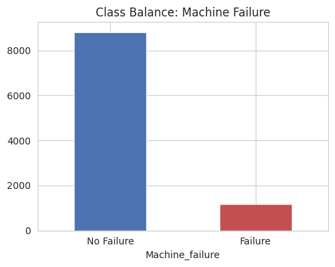

```python
fig, ax = plt.subplots(figsize=(5,4))
df["Machine_failure"].value_counts().plot(kind="bar", ax=ax, color=["#4C72B0", "#C44E52"])
ax.set_xticklabels(["No Failure", "Failure"], rotation=0)
ax.set_title("Class Balance: Machine Failure")
plt.tight_layout(); plt.show()
```

The dataset is **imbalanced** (~12% failure rate) — realistic for industrial settings, and something our modeling approach needs to account for explicitly.

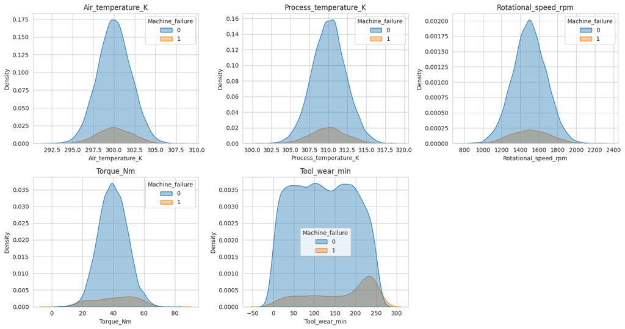

```python
numeric_cols = ["Air_temperature_K", "Process_temperature_K",
                 "Rotational_speed_rpm", "Torque_Nm", "Tool_wear_min"]

fig, axes = plt.subplots(2, 3, figsize=(15, 8))
axes = axes.flatten()
for i, col in enumerate(numeric_cols):
    sns.kdeplot(data=df, x=col, hue="Machine_failure", fill=True, alpha=0.4, ax=axes[i])
    axes[i].set_title(col)
axes[-1].axis("off")
plt.tight_layout(); plt.show()
```

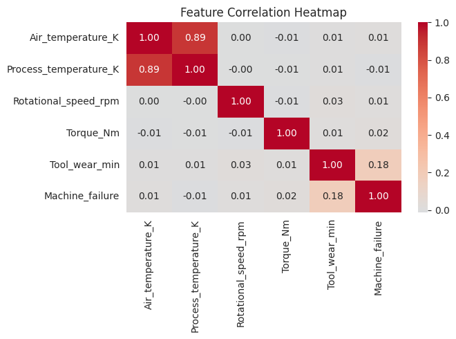

```python
corr = df[numeric_cols + ["Machine_failure"]].corr()
fig, ax = plt.subplots(figsize=(7,5))
sns.heatmap(corr, annot=True, cmap="coolwarm", center=0, fmt=".2f", ax=ax)
ax.set_title("Feature Correlation Heatmap")
plt.tight_layout(); plt.show()
```

**Observation:** raw sensor readings correlate weakly with failure. This is expected — real failures come from *interactions* between variables (e.g. high torque **combined with** high tool wear), not any single sensor in isolation. This motivates the feature engineering step below.

## 4. Feature Engineering

We add physics-informed interaction features that mirror the actual failure mechanisms (heat dissipation, power failure, overstrain):

```python
def engineer_features(df):
    df = df.copy()
    df["Temp_diff_K"] = df["Process_temperature_K"] - df["Air_temperature_K"]
    df["Power_W"] = df["Torque_Nm"] * (df["Rotational_speed_rpm"] * 2 * np.pi / 60)
    df["Strain"] = df["Tool_wear_min"] * df["Torque_Nm"]
    df["Wear_per_speed"] = df["Tool_wear_min"] / (df["Rotational_speed_rpm"] + 1)
    return df

df_fe = engineer_features(df)

feature_cols = ["Type", "Air_temperature_K", "Process_temperature_K",
                "Rotational_speed_rpm", "Torque_Nm", "Tool_wear_min",
                "Temp_diff_K", "Power_W", "Strain", "Wear_per_speed"]

X = df_fe[feature_cols]
y = df_fe["Machine_failure"]

categorical = ["Type"]
numeric = [c for c in feature_cols if c not in categorical]

preprocessor = ColumnTransformer([
    ("num", StandardScaler(), numeric),
    ("cat", OneHotEncoder(drop="first"), categorical),
])

X_train, X_test, y_train, y_test = train_test_split(
    X, y, test_size=0.2, random_state=RANDOM_STATE, stratify=y
)
print(f"Train: {len(X_train)}  Test: {len(X_test)}")
```

```
Train: 8000  Test: 2000
```

## 5. Model Training & Comparison

We compare three classifiers, all with class-imbalance handling enabled (`class_weight='balanced'` / `scale_pos_weight`):

```python
models = {
    "Logistic Regression": LogisticRegression(max_iter=1000, class_weight="balanced", random_state=RANDOM_STATE),
    "Random Forest": RandomForestClassifier(n_estimators=300, max_depth=10, class_weight="balanced",
                                             random_state=RANDOM_STATE, n_jobs=-1),
    "XGBoost": XGBClassifier(n_estimators=300, max_depth=5, learning_rate=0.1,
                              scale_pos_weight=(y_train==0).sum()/(y_train==1).sum(),
                              random_state=RANDOM_STATE, eval_metric="logloss"),
}

results = {}
fitted = {}
roc_data = {}
pr_data = {}

for name, clf in models.items():
    pipe = Pipeline([("preprocess", preprocessor), ("classifier", clf)])
    pipe.fit(X_train, y_train)
    fitted[name] = pipe

    y_pred = pipe.predict(X_test)
    y_proba = pipe.predict_proba(X_test)[:, 1]

    report = classification_report(y_test, y_pred, output_dict=True)
    results[name] = {
        "precision": report["1"]["precision"],
        "recall": report["1"]["recall"],
        "f1": f1_score(y_test, y_pred),
        "roc_auc": roc_auc_score(y_test, y_proba),
        "pr_auc": average_precision_score(y_test, y_proba),
    }
    roc_data[name] = roc_curve(y_test, y_proba)[:2]
    pr_data[name] = precision_recall_curve(y_test, y_proba)[:2]

pd.DataFrame(results).T.round(4)
```

|  | precision | recall | f1 | roc_auc | pr_auc |
| --- | --- | --- | --- | --- | --- |
| Logistic Regression | 0.2003 | 0.6498 | 0.3062 | 0.7088 | 0.3262 |
| Random Forest | 0.4116 | 0.5992 | 0.4880 | 0.8352 | 0.4013 |
| XGBoost | 0.4083 | 0.5823 | 0.4800 | 0.8214 | 0.4004 |

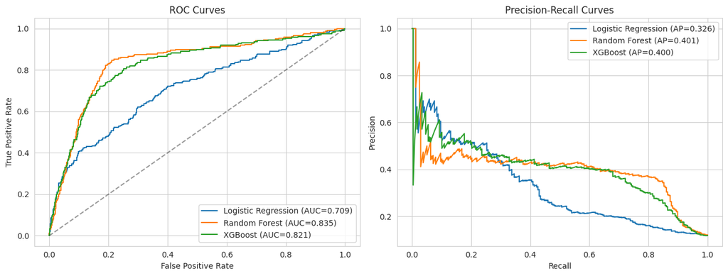

```python
fig, axes = plt.subplots(1, 2, figsize=(13,5))

for name, (fpr, tpr) in roc_data.items():
    axes[0].plot(fpr, tpr, label=f"{name} (AUC={results[name]['roc_auc']:.3f})")
axes[0].plot([0,1],[0,1],"k--", alpha=0.4)
axes[0].set_xlabel("False Positive Rate"); axes[0].set_ylabel("True Positive Rate")
axes[0].set_title("ROC Curves"); axes[0].legend()

for name, (prec, rec) in pr_data.items():
    axes[1].plot(rec, prec, label=f"{name} (AP={results[name]['pr_auc']:.3f})")
axes[1].set_xlabel("Recall"); axes[1].set_ylabel("Precision")
axes[1].set_title("Precision-Recall Curves"); axes[1].legend()

plt.tight_layout(); plt.show()
```

## 6. Best Model — Detailed Evaluation

```
Best model: Random Forest
              precision    recall  f1-score   support

  No Failure       0.94      0.88      0.91      1763
     Failure       0.41      0.60      0.49       237

    accuracy                           0.85      2000
   macro avg       0.68      0.74      0.70      2000
weighted avg       0.88      0.85      0.86      2000
```

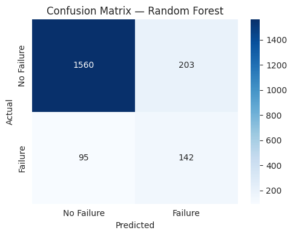

```python
best_name = max(results, key=lambda k: results[k]["f1"])
best_pipe = fitted[best_name]
print(f"Best model: {best_name}")

y_pred_best = best_pipe.predict(X_test)
print(classification_report(y_test, y_pred_best, target_names=["No Failure", "Failure"]))

cm = confusion_matrix(y_test, y_pred_best)
fig, ax = plt.subplots(figsize=(5,4))
sns.heatmap(cm, annot=True, fmt="d", cmap="Blues",
            xticklabels=["No Failure","Failure"], yticklabels=["No Failure","Failure"], ax=ax)
ax.set_xlabel("Predicted"); ax.set_ylabel("Actual")
ax.set_title(f"Confusion Matrix — {best_name}")
plt.tight_layout(); plt.show()
```

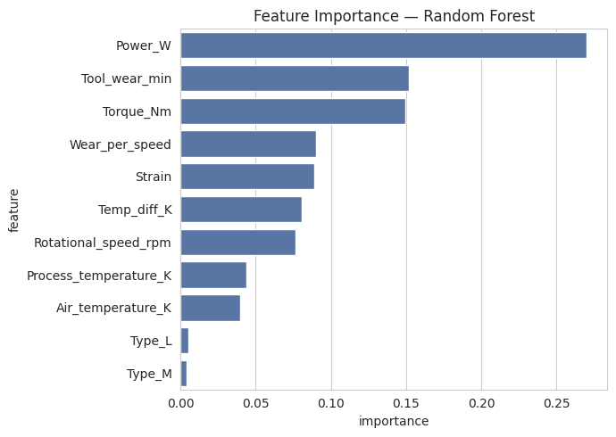

```python
classifier = best_pipe.named_steps["classifier"]
if hasattr(classifier, "feature_importances_"):
    ohe_cols = list(best_pipe.named_steps["preprocess"].named_transformers_["cat"].get_feature_names_out(["Type"]))
    all_cols = numeric + ohe_cols
    imp_df = pd.DataFrame({"feature": all_cols, "importance": classifier.feature_importances_})
    imp_df = imp_df.sort_values("importance", ascending=False)

    fig, ax = plt.subplots(figsize=(7,5))
    sns.barplot(data=imp_df, x="importance", y="feature", ax=ax, color="#4C72B0")
    ax.set_title(f"Feature Importance — {best_name}")
    plt.tight_layout(); plt.show()
```

## 7. Save the Model

```python
import joblib
joblib.dump(best_pipe, "models/best_model.joblib")
joblib.dump(feature_cols, "models/feature_cols.joblib")
print("Saved.")
```

```
Saved.
```

## 8. Example Inference

```python
def predict_failure(air_temp, process_temp, rot_speed, torque, tool_wear, machine_type="M"):
    raw = pd.DataFrame([{
        "Type": machine_type, "Air_temperature_K": air_temp, "Process_temperature_K": process_temp,
        "Rotational_speed_rpm": rot_speed, "Torque_Nm": torque, "Tool_wear_min": tool_wear,
    }])
    X_new = engineer_features(raw)[feature_cols]
    proba = best_pipe.predict_proba(X_new)[0, 1]
    pred = best_pipe.predict(X_new)[0]
    risk = "Low" if proba < 0.2 else "Medium" if proba < 0.5 else "High"
    return {"prediction": int(pred), "failure_probability": round(float(proba), 4), "risk_level": risk}

# High tool wear + high torque -> overstrain risk
predict_failure(air_temp=300.0, process_temp=310.0, rot_speed=1400, torque=60, tool_wear=230, machine_type="L")
```

```
{'prediction': 1, 'failure_probability': 0.5602, 'risk_level': 'High'}
```

## 9. Conclusions

- Random Forest / XGBoost substantially outperform Logistic Regression, confirming that failure risk is driven by **non-linear interactions** between sensor readings rather than any single reading in isolation.
- The engineered `Power_W`, `Strain`, and `Temp_diff_K` features rank among the most important predictors — validating the domain-informed feature engineering approach.
- Because failures are rare (~12%), **precision/recall/F1 and ROC-AUC/PR-AUC** are the right metrics to optimize and report — not raw accuracy.
- See `README.md` for full discussion of limitations and future work (time-series modeling, multi-class failure-mode prediction, threshold tuning for cost-sensitive deployment).